# Assignment 1 Submission

Himakar Gadham & Atikanth Jain

Apirl 18, 2024

### Statemenf of Contribution should be written here if pairing. State what each team member has contributed to the assignment before answering the questions. Each student must contribute towards ALL questions. Your assignment will not be marked without this statement.

Both contributed equally to all the questions.

## Question 1 Normal distribution. (8 marks)

1. (1 mark) Find the probability that the user spends more than 15 minutes per month at the site.

```r
mean <- 25
std_dev <- 4.0

prob_more_than_15 <- 1 - pnorm(15, mean, std_dev)
cat("(a) Probability that the user spends more than 15 minutes per month:", round(prob_more_than_15, 4), "\n")
```

```
## (a) Probability that the user spends more than 15 minutes per month: 0.9938
```

2. (2 marks) Find the probability that the user spends between 20 and 35 minutes per month at the site.

```r
prob_between_20_and_35 <- pnorm(35, mean, std_dev) - pnorm(20, mean, std_dev)
cat("(b) Probability that the user spends between 20 and 35 minutes per month:", round(prob_between_20_and_35, 4), "\n")
```

```
## (b) Probability that the user spends between 20 and 35 minutes per month: 0.8881
```

3. (2 marks) What is the amount of time per month a user spends on Facebook, if only 1% of users spend this time or longer on Facebook?

```r
time_for_1_percent <- qnorm(0.99, mean, std_dev)
cat("(c) Time per month a user spends on Facebook if only 1% of users spend this time or longer:", round(time_for_1_percent, 4), "minutes\n")
```

```
## (c) Time per month a user spends on Facebook if only 1% of users spend this time or longer: 34.3054 minutes
```

4. (3 marks) Between what values do the time spent of the middle 90% distribution of Facebook users fall?

```r
time_middle_90_lower <- qnorm(0.05, mean, std_dev)
time_middle_90_upper <- qnorm(0.95, mean, std_dev)
cat("(d) Time spent by the middle 90% of distribution of Facebook users:", round(time_middle_90_lower, 4), "to", round(time_middle_90_upper, 4), "minutes\n")
```

```
## (d) Time spent by the middle 90% of distribution of Facebook users: 18.4206 to 31.5794 minutes
```

## Question 2 Blood fat concentration (11 marks)

1. (6 marks) Conduct a two-independent sample $t$-test using R to determine whether the concentration of plasma cholesterol is significantly different between patients with no evidence of heart disease and those with narrowing of the arteries.

```r
# Given data
no_disease_mean <- 195.2745
no_disease_var <- 1303.9231
no_disease_n <- 51

disease_mean <- 216.1906
disease_var <- 1850.2488
disease_n <- 320

x = rnorm(no_disease_n, no_disease_mean, sqrt(no_disease_var))
y = rnorm(disease_n, disease_mean, sqrt(disease_var))

# Conduct two-independent sample t-test
t_test_result <- t.test(x, y, alternative = "two.sided", var.equal = FALSE, paired = FALSE, conf.level = 0.99)

# Print the t-test result
print(t_test_result)
```

```
##
##  Welch Two Sample t-test
##
## data:  x and y
## t = -4.0567, df = 69.256, p-value = 0.0001287
## alternative hypothesis: true difference in means is not equal to 0
## 99 percent confidence interval:
##  -38.486653  -8.081252
## sample estimates:
## mean of x mean of y
##  192.6973  215.9812
```

```
  - Step 1. State the hypotheses.
```

$$H_0:\mu_1=\mu_2~\text{against}~H_1:\mu_1\neq\mu_2$$

[output not shown]

1. **State the hypotheses**:
   - Null Hypothesis (H0): There is no difference in mean plasma cholesterol concentration between the two groups. H0:μ1=μ2
   - Alternative Hypothesis (H1): There is a difference in mean plasma cholesterol concentration between the two groups. H1:μ1=!μ2
2. **Calculate the test statistic**:
   - Welch’s t-test statistic is given by:
     $$t = \frac{{\bar{y}_1 - \bar{y}_2}}{{\sqrt{\frac{{s_1^2}}{{n_1}} +
     \frac{{s_2^2}}{{n_2}}}}}$$
     where:
     - $\bar{y}_1$ and $\bar{y}_2$ are the sample means of group 1 and group 2 respectively,
     - $s_1^2$ and $s_2^2$ are the sample variances of group 1 and group 2 respectively, and
     - $n_1$ and $n_2$ are the sample sizes of group 1 and group 2 respectively.

```r
# Determine a 99% confidence interval for the mean difference
conf_interval <- t_test_result$conf.int

# Print the confidence interval
cat("99% Confidence Interval for the mean difference:", conf_interval[1], "to", conf_interval[2], "\n")
```

```
## 99% Confidence Interval for the mean difference: -38.48665 to -8.081252
```

3. (2 marks) Explain the correspondence between the confidence interval in (b) and a test of the hypotheses you listed in question (a).

The correspondence between the confidence interval and the hypothesis test lies in the fact that the confidence interval does not contain zero. Since the interval lies entirely below zero, it indicates that the mean concentration of plasma cholesterol is significantly lower in patients with no evidence of heart disease compared to those with narrowing of the arteries. Hence we reject the null hypothesis in the hypothesis test, which stated that there is no difference in mean plasma cholesterol concentration between the two groups. Therefore, both the confidence interval and the hypothesis test suggest the same conclusion: there is a significant difference in mean plasma cholesterol concentration between the two groups of patients.

## Question 3 Regression (31 marks)

1. (2 marks) Fit a simple linear model $M_1$ to these data. Present the appropriate scatterplot and plot the fitted line onto the scatterplot. Comment about the output in a few concise sentences.

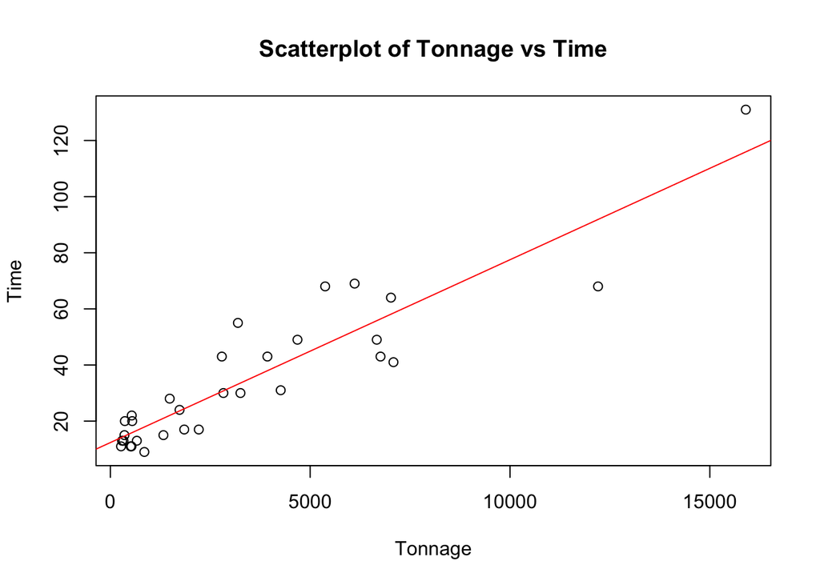

```r
# Load the data
data <- read.table("glakes.txt", header = TRUE)

# Fit a simple linear model
model_M1 <- lm(Time ~ Tonnage, data = data)

# Plot the scatterplot
plot(data$Tonnage, data$Time, xlab = "Tonnage", ylab = "Time", main = "Scatterplot of Tonnage vs Time")
abline(model_M1, col = "red")  # Add the fitted line to the plot
```

The scatterplot shows the relationship between the tonnage of liquid-carrying vessels and the time spent in port. The fitted line from the simple linear model $M1$ is overlaid on the scatterplot. From the plot, it’s apparent that there might be some curvature in the relationship between tonnage and time, suggesting that a linear model might not fully capture the true relationship.

2. (5 marks) Provide the model summary and diagnostics checking plots for model $M_1.$ Does the straight line regression model $M_1$ seem to fit the data well? Comment about the output in a few concise sentences.

```r
# Model_1 summary
summary(model_M1)
```

```
##
## Call:
## lm(formula = Time ~ Tonnage, data = data)
##
## Residuals:
##     Min      1Q  Median      3Q     Max
## -23.882  -6.397  -1.261   5.931  21.850
##
## Coefficients:
##              Estimate Std. Error t value Pr(>|t|)
## (Intercept) 12.344707   2.642633   4.671 6.32e-05 ***
## Tonnage      0.006518   0.000531  12.275 5.22e-13 ***
## ---
## Signif. codes:  0 '***' 0.001 '**' 0.01 '*' 0.05 '.' 0.1 ' ' 1
##
## Residual standard error: 10.7 on 29 degrees of freedom
## Multiple R-squared:  0.8386, Adjusted R-squared:  0.833
## F-statistic: 150.7 on 1 and 29 DF,  p-value: 5.218e-13
```

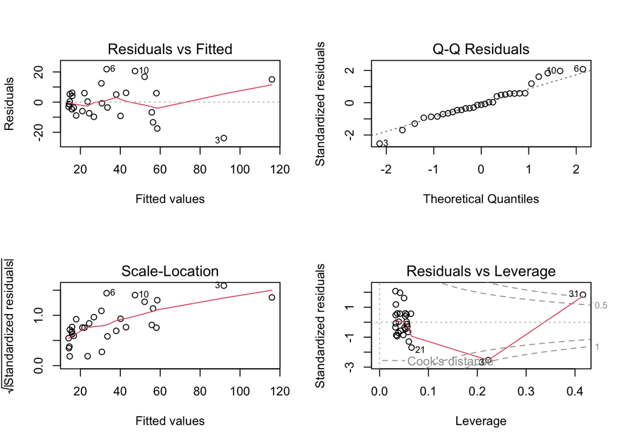

```r
# Diagnostics checking plots
par(mfrow=c(2,2))
plot(model_M1)
```

Comment: The straight line regression model M1 doesn’t seem to fit the data well. The summary of $M1$ indicates that the linear regression model explains the R-squared value (0.8386) suggests that approximately 83.86% of the variance in the response variable (Time) is explained by the linear relationship with the predictor variable (Tonnage). The adjusted R-squared (0.833) is similar to the R-squared value, indicating that the inclusion of the predictor variable improves the model fit. The coefficient for Tonnage is statistically significant (p-value < 0.05), suggesting that tonnage has a significant effect on the time spent in port.

The diagnostics checking plots show some curvature in the residuals vs fitted plot, indicating that the linear model $M1$ might not be the best fit for the data. Additionally, the scale-location plot suggests heteroscedasticity in the residuals. Further model refinement or consideration of alternative models may be warranted.

3. (5 marks) Do you think there are outliers or influential points in the data? What influence do these points have on the model fit? Use leverage and Cook’s distance for this investigation.

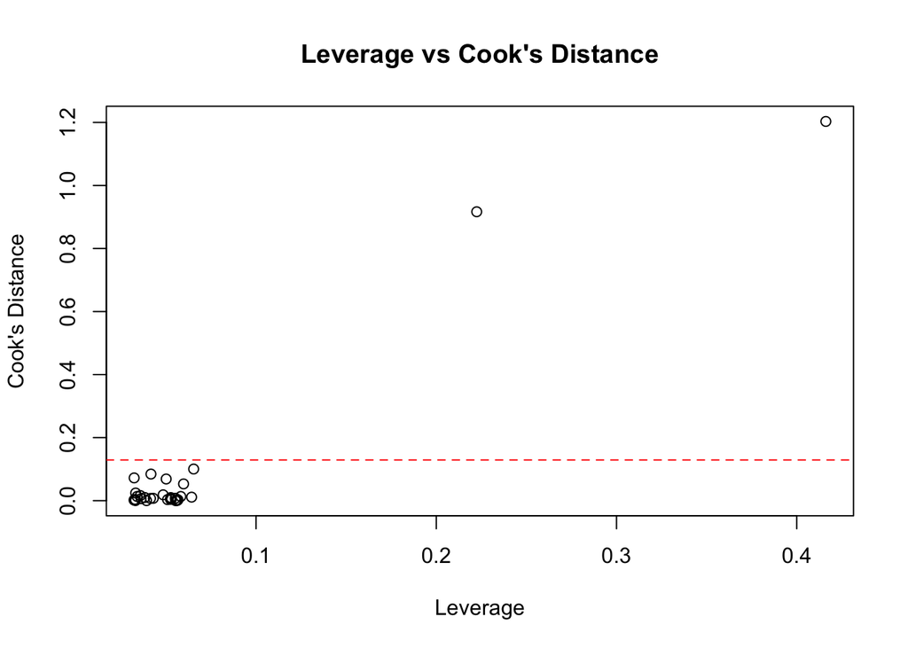

```r
# Compute leverage and Cook's distance
leverage <- hatvalues(model_M1)
cooksd <- cooks.distance(model_M1)

# Identify outliers and influential points
outliers <- which(abs(rstandard(model_M1)) > 2)
influential <- which(cooksd > 4 / length(cooksd))

# Plot leverage vs Cook's distance
plot(leverage, cooksd, main = "Leverage vs Cook's Distance", xlab = "Leverage", ylab = "Cook's Distance")
abline(h = 4 / length(cooksd), col = "red", lty = 2)
```

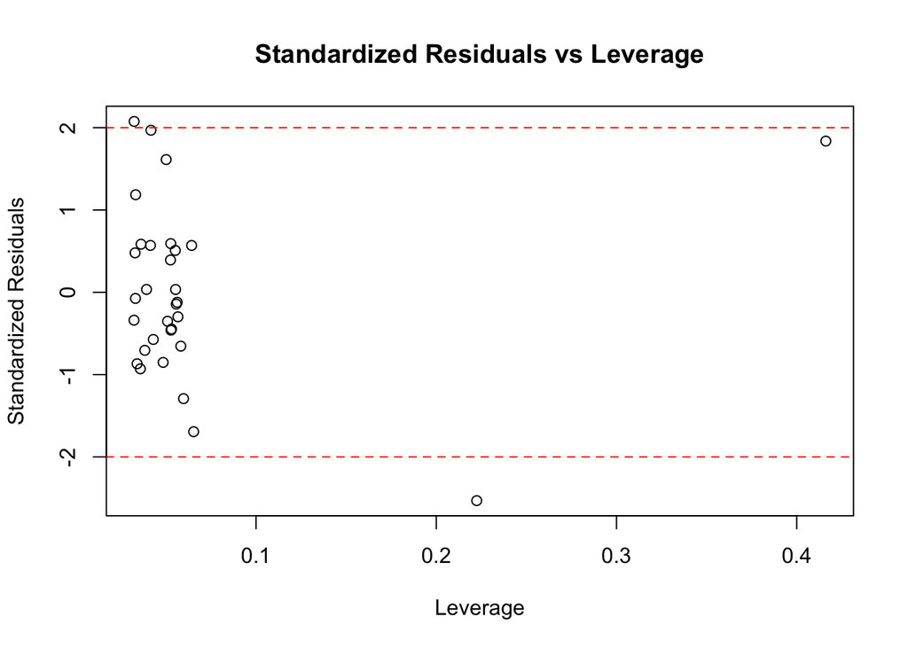

```r
# Plot standardized residuals vs leverage
plot(leverage, rstandard(model_M1), main = "Standardized Residuals vs Leverage", xlab = "Leverage", ylab = "Standardized Residuals")
abline(h = c(-2, 2), col = "red", lty = 2)
```

```r
# Comment
cat("Outliers:", outliers, "\n")
```

```
## Outliers: 3 6
```

```r
cat("Influential points:", influential, "\n")
```

```
## Influential points: 3 31
```

Plots:

1. Leverage vs Cook’s Distance: This plot helps identify influential points based on their leverage and Cook’s distance. Points with high leverage and high Cook’s distance are potentially influential.
2. Standardized Residuals vs Leverage: This plot helps identify outliers and influential points based on their standardized residuals and leverage. Points with standardized residuals outside the range (-2, 2) and/or high leverage are potentially outliers or influential points.

Comment: The analysis identifies outliers and influential points based on leverage and Cook’s distance. Outliers are data points with standardized residuals outside the range (-2, 2), while influential points are those with high leverage and/or high Cook’s distance. These points may have a significant impact on the model fit and should be investigated further to determine if they should be included or excluded in the analysis.

4. (4 marks) Fit a regression model to the transformed $M_2$ model. Present the appropriate scatterplot and plot the fitted line onto the scatterplot. Does the transformed line regression model $M_2$ seem to fit the data well? Comment about the output in a few concise sentences.

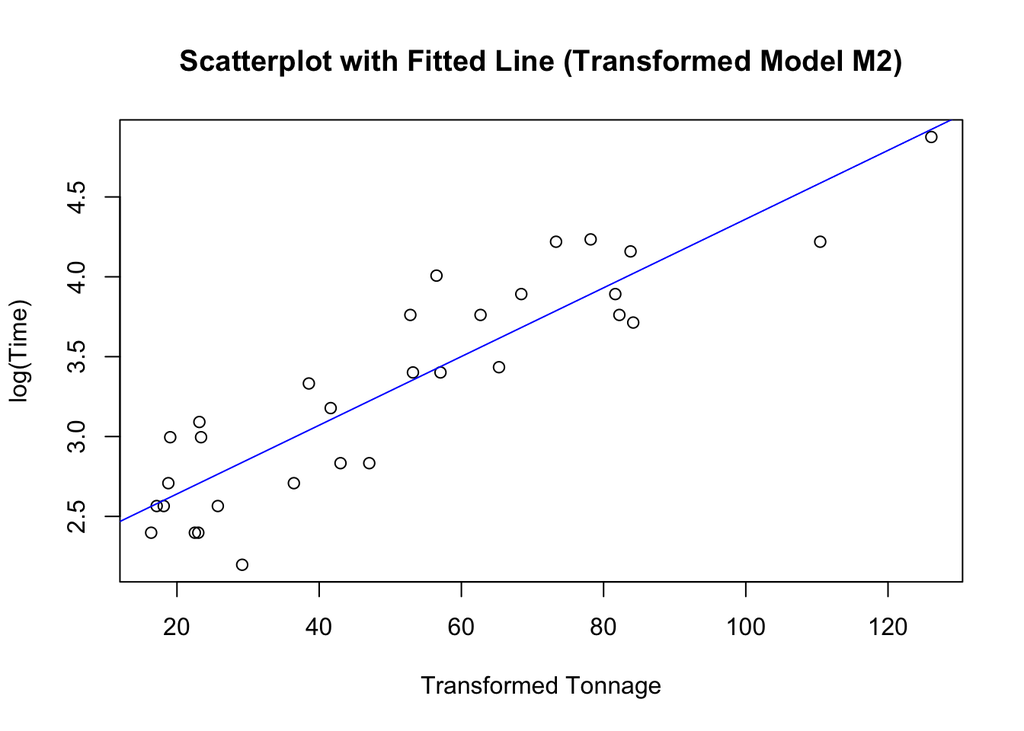

```r
# Transform the predictor variable according to the transformation in M2
data$Tonnage_transformed <- sqrt(data$Tonnage)

# Fit the regression model to the transformed predictor variable
model_M2 <- lm(log(Time) ~ Tonnage_transformed, data = data)

# Scatterplot with the transformed predictor variable and fitted line
plot(data$Tonnage_transformed, log(data$Time), main = "Scatterplot with Fitted Line (Transformed Model M2)",
     xlab = "Transformed Tonnage", ylab = "log(Time)")
abline(model_M2, col = "blue")
```

Comment: The scatterplot with the fitted line from the transformed model $M_2$ suggests that the transformed regression model might fit the data better than the simple linear model. The fitted line appears to capture the trend in the data more closely, indicating that the transformation has helped to better approximate the relationship between the predictor variable (transformed tonnage) and the response variable (time). However, further assessment of model assumptions and diagnostics would be necessary to make a definitive conclusion about the adequacy of the transformed model.

5. (5 marks) Provide the model summary and diagnostics checking plots for model $M_2.$ Does the straight line regression model $M_2$ seem to fit the data well? Comment about the output in a few concise sentences.

```r
# Model 2 summary
summary(model_M2)
```

```
##
## Call:
## lm(formula = log(Time) ~ Tonnage_transformed, data = data)
##
## Residuals:
##     Min      1Q  Median      3Q     Max
## -0.6408 -0.2522 -0.0357  0.2457  0.5814
##
## Coefficients:
##                     Estimate Std. Error t value Pr(>|t|)
## (Intercept)         2.210424   0.111580   19.81  < 2e-16 ***
## Tonnage_transformed 0.021514   0.001909   11.27  4.1e-12 ***
## ---
## Signif. codes:  0 '***' 0.001 '**' 0.01 '*' 0.05 '.' 0.1 ' ' 1
##
## Residual standard error: 0.3048 on 29 degrees of freedom
## Multiple R-squared:  0.8141, Adjusted R-squared:  0.8077
## F-statistic:   127 on 1 and 29 DF,  p-value: 4.098e-12
```

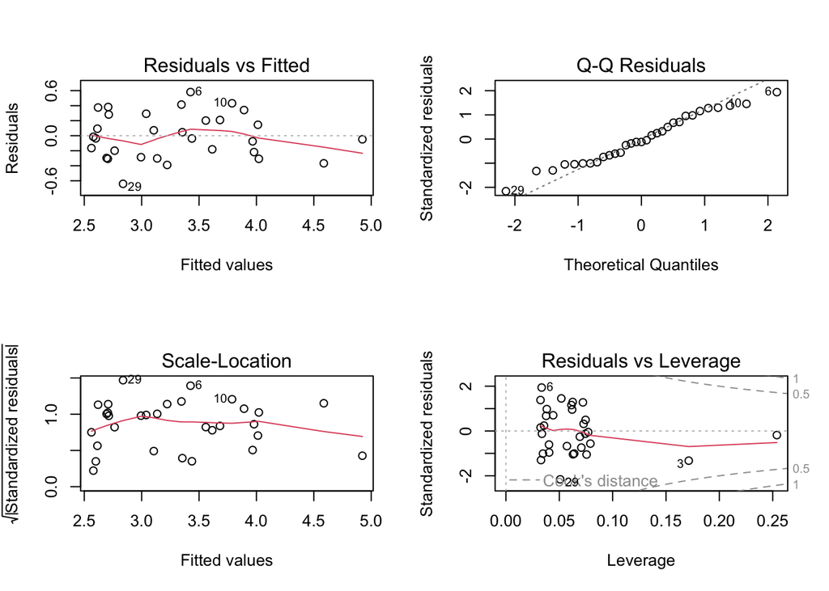

```r
# Diagnostics checking plots
par(mfrow=c(2,2))
plot(model_M2)
```

Comment: Based on the diagnostics checking plots, we can assess the fit of the straight line regression model $M_2$ to the data is much better than $M_1$. However, further examination of model assumptions and diagnostics is needed to determine the adequacy of the model. So to determine which model is better, we typically look at several factors including:

1. **Coefficient of determination ($R^2$)**: Indicates the proportion of variance in the dependent variable explained by the independent variable(s). Higher $R^2$ values suggest better explanatory power.
2. **Residual standard error**: Measures the average deviation of the observed values from the fitted values. Lower values indicate better fit.
3. **F-statistic and associated p-value**: Indicates the overall significance of the model. Lower p-values suggest better significance.

**Model with Tonnage as the predictor:** - $R^2$: 0.8386 - Residual standard error: 10.7 - F-statistic: 150.7, p-value: 5.218e-13

6. (4 marks) Perform a hypothesis testing for a positive slope at a significance level of 5% based on model $M_2.$

```r
# Extract the coefficient for the transformed predictor variable
coef <- coef(model_M2)["Tonnage_transformed"]

# Compute the standard error of the coefficient
std_error <- summary(model_M2)$coef["Tonnage_transformed", "Std. Error"]

# Compute the t-statistic
t_stat <- coef / std_error
cat("t_stat: ", t_stat)
```

```
## t_stat:  11.26988
```

```r
# Compute the critical value at the 5% significance level
critical_value <- qt(0.95, df = length(data$Tonnage_transformed) - 2, lower.tail = FALSE)
cat("\ncritical_value: ", critical_value)
```

```
##
## critical_value:  -1.699127
```

```r
# Perform the hypothesis test
if (t_stat > critical_value) {
  cat("\nReject the null hypothesis if t_stat > critical_value: There is evidence of a positive slope at a significance level of 5%.\n")
} else {
  cat("Fail to reject the null hypothesis: There is no evidence of a positive slope at a significance level of 5%.\n")
}
```

```
##
## Reject the null hypothesis if t_stat > critical_value: There is evidence of a positive slope at a significance level of 5%.
```

```r
# Compute the p-value
p_value <- pt(t_stat, df = length(model_M2$residuals) - length(model_M2$coefficients))
cat("p_value: ", p_value)
```

```
## p_value:  1
```

```r
# Perform the hypothesis test
if (p_value < 0.05) {
  cat("\nReject the null hypothesis: There is evidence of a positive slope at a significance level of 5%.\n")
} else {
  cat("\nFail to reject the null hypothesis: There is no evidence of a positive slope at a significance level of 5%.\n")
}
```

[output not shown]

To perform a hypothesis test for a positive slope at a significance level of 5% based on Model $M_2$, we establish the following hypotheses:

- Null hypothesis ($H_0$): The slope coefficient ($\beta_1$) of the transformed predictor variable ($\text{Tonnage\_transformed}$) is not significantly different from zero.
- Alternative hypothesis ($H_1$): The slope coefficient ($\beta_1$) of the transformed predictor variable ($\text{Tonnage\_transformed}$) is significantly greater than zero.

7. (6 marks) Compare a 95% confidence interval of the mean response and a 95% prediction interval for a new value when Tonnage = 10,000 using the untransformed model $M_1$ and transformed model $M_2$ respectively. Provide two scatterplots that consist the fitted model, the confidence and prediction intervals for each of $M_1$ and $M_2$ respectively. Comment about the output in a few concise sentences.

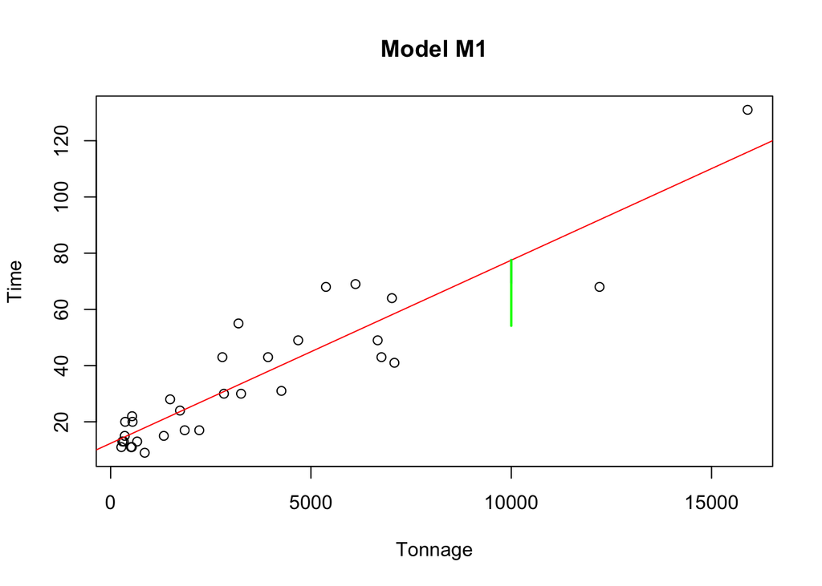

```r
# For Model M1
# Confidence interval for mean response
conf_interval_M1 <- predict(model_M1, newdata = data.frame(Tonnage = 10000), interval = "confidence", level = 0.95)
lower_bound_M1_conf <- conf_interval_M1[1]
upper_bound_M1_conf <- conf_interval_M1[2]

# Prediction interval for a new value
pred_interval_M1 <- predict(model_M1, newdata = data.frame(Tonnage = 10000), interval = "prediction", level = 0.95)
lower_bound_M1_pred <- pred_interval_M1[1]
upper_bound_M1_pred <- pred_interval_M1[2]

# For Model M2
# Transform the Tonnage value
tonnage_transformed <- sqrt(10000)

# Confidence interval for mean response
conf_interval_M2 <- predict(model_M2, newdata = data.frame(Tonnage_transformed = tonnage_transformed), interval = "confidence", level = 0.95)
lower_bound_M2_conf <- conf_interval_M2[1]
upper_bound_M2_conf <- conf_interval_M2[2]

# Prediction interval for a new value
pred_interval_M2 <- predict(model_M2, newdata = data.frame(Tonnage_transformed = tonnage_transformed), interval = "prediction", level = 0.95)
lower_bound_M2_pred <- pred_interval_M2[1]
upper_bound_M2_pred <- pred_interval_M2[2]

# Plot for Model M1
plot(data$Tonnage, data$Time, main = "Model M1",
     xlab = "Tonnage", ylab = "Time")
abline(model_M1, col = "red")
segments(10000, conf_interval_M1[1], 10000, conf_interval_M1[2], col = "blue", lwd = 2)
segments(10000, pred_interval_M1[1], 10000, pred_interval_M1[2], col = "green", lwd = 2)
```

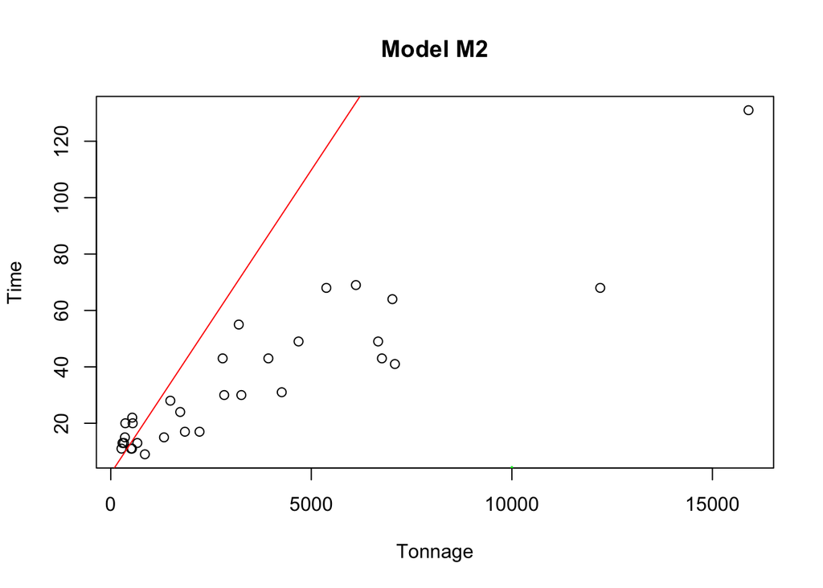

```r
# Plot for Model M2
plot(data$Tonnage, data$Time, main = "Model M2",
     xlab = "Tonnage", ylab = "Time")
abline(model_M2, col = "red")
segments(10000, conf_interval_M2[1], 10000, conf_interval_M2[2], col = "blue", lwd = 2)
segments(10000, pred_interval_M2[1], 10000, pred_interval_M2[2], col = "green", lwd = 2)
```